# Design of “climagrams” for C3S seasonal forecast products

Preliminary working document

J. Bedia, R. Manzanas, J. Bhend, D. San-Martín, F.J. Doblas-Reyes

Jun 21, 2018

Abstract

The so called climagrams have been identified as a seasonal forecast product to be delivered by C3S. As a proof-of-concept, the QA4Seas prototype will produce this type of graphical product. Two essential conditions need to be met. (i) The product should bear some for of EQC information in addition to provide forecast information and (ii) The product should be tailored to the display of multimodel (calibrated) forecasts. It is also desirable that the amount of information displayed is limited, to avoid a congested display.  
In this document we present a first version of climagrams and the different options available, aimed at promoting a discussion focused on the required features. Aesthetic aspects are of less importance, given that the QA4Seas prototype won’t be included in the CDS toolbox.  
In the last section, examples of multimodel combination (raw and calibrated) are given in order to illustrate the importance of proper calibration with multi-model combination and how climagrams can help as an assessment tool.

# 1 Introduction

## 1.1 Required R packages

The implementation of climagrams here presented is part of the R package `visualizeR` (Frías *et al.* 2018). This package is part of a R-based framework for climate data access, analysis and transformation known as [climate4R](http://www.meteo.unican.es/climate4r). A couple of packages need to be installed to reproduce the examples below, hosted in the public Santander MetGroup [GitHub repository](https://github.com/SantanderMetGroup). To this aim, the usage of `devtools` function `install_github` is recommended:

```r
devtools::install_github("SantanderMetGroup/transformeR",
                         "SantanderMetGroup/visualizeR@climagram")
```

In addition, the R package `calibratoR` (Manzanas *et al.* 2018) has been developed to be used in the QA4Seas prototype for model calibration.

```r
devtools::install_github("SantanderMetGroup/calibratoR")
```

## 1.2 Required datasets

In this example, the following datasets will be used:

- The NCEP-NCAR Reanalysis 1, used as reference for verification purposes
- The NCEP CFSv2 seasonal hindcast (24 members)
- The NCEP CFSv2 seasonal operative predictions (DJF 2016)

In addition, in order to illustrate multimodel ensemble climagrams, two additional hindcasts are used:

- The ECMWF System-4 (51 members)
- The UKMO-GloSea5 system (24 members)

All data correspond to the ENSO 3.4 region, for the variable 2m air temperature, and have been interpolated onto de NCEP regular grid (2.5º hor. res.). The season is boreal winter (DJF), and the hindcast period is 1983-2009 (CFSv2), 1982-2010 (System4) and 1993-2012 (GloSea5). All data have been retrieved from the User Data Gateway using the R package `loadeR.ECOMS` (Cofiño *et al.* 2018). The data structure is according to the `climate4R` common data model.

The data have been prepared to be readily available in order to reproduce the examples. To ease access, and avoid potential problems related with remote data load, the following function can be used:

```r
my_load <- function(file.url) {
    tmpfile <- tempfile()
    download.file(url = file.url, destfile = tmpfile)
    readRDS(tmpfile)
}
```

Further usage details are provided in the function help doc:

```r
library(visualizeR)
help("climagram")
```

# 2 Single-model climagram

## 2.1 Climagrams without EQC information

In its most basic form, the climagram does not display any EQC info, and just presents the information of the forecast together with the hindcast climatology. The function will read the metadata stored within the climate4R CDM objects, and will automatically generate the title of the plot, axis labels etc (still need to be tuned to properly handle multimodel names, work is in progress). The function will perform all the necessary checks to ensure the consistency of the input data (spatiotemporal ranges etc.). We next load the data corresponding to the CFSv2 hindcast (`cfs.hindcast`) and operational forecast predictions (2016, `cfs.forecast`)

```r
cfs.hindcast <- my_load("http://meteo.unican.es/work/visualizeR/data/tas.cfs.enso34.rds")
cfs.forecast <- my_load("http://meteo.unican.es/work/visualizeR/data/tas.cfs.2016.enso34.rds")
```

### 2.1.1 Basic usage

Here is a basic example, in which only hindcast and forecast are passed to the function, using the default values for the rest of arguments:

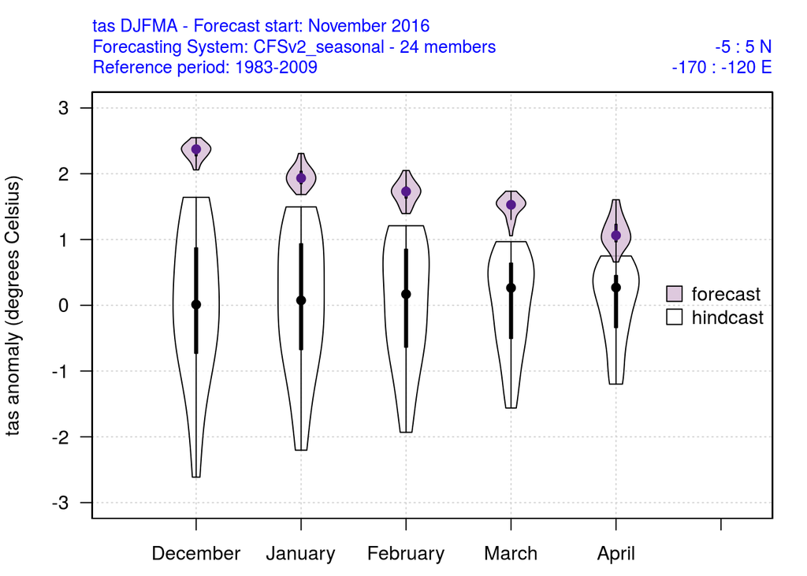

```r
climagram(hindcast = cfs.hindcast, forecast = cfs.forecast)
```

### 2.1.2 Using boxplots

By default, the function will display “violins” to represent the ensemble spread, which are in essence a combination of a box plot and a kernel density plot. Ordinary boxplots can be used instead of violins by setting the argument `violin` to `FALSE`:

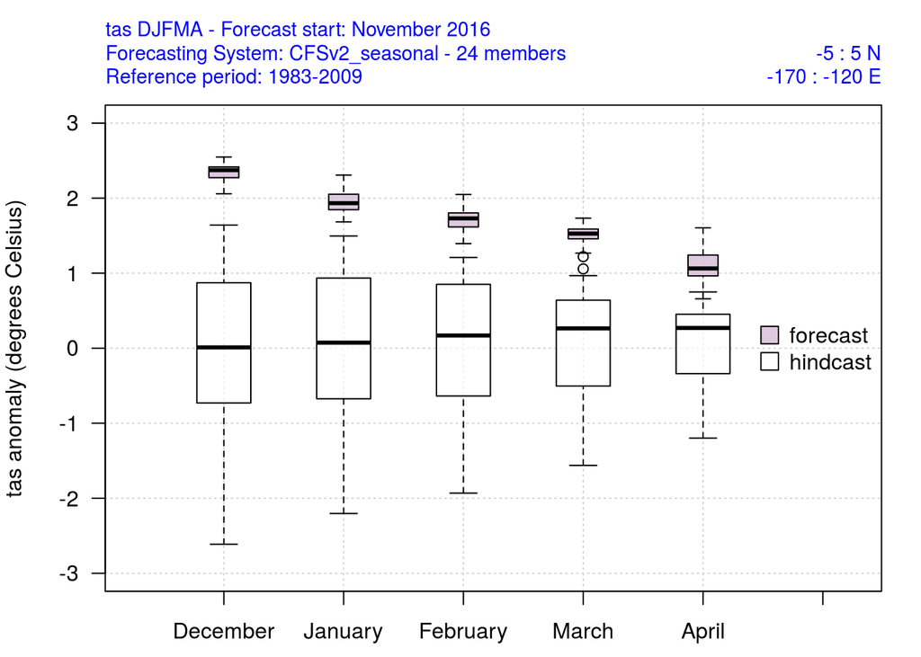

```r
climagram(hindcast = cfs.hindcast, forecast = cfs.forecast, violin = FALSE)
```

### 2.1.3 Adding individual members

Additionally, members can be individually displayed (`add.points = TRUE`), although this option often leads to a visually cluttered plot, particularly in the extreme prediction of year 2016, that has a very low ensemble spread:

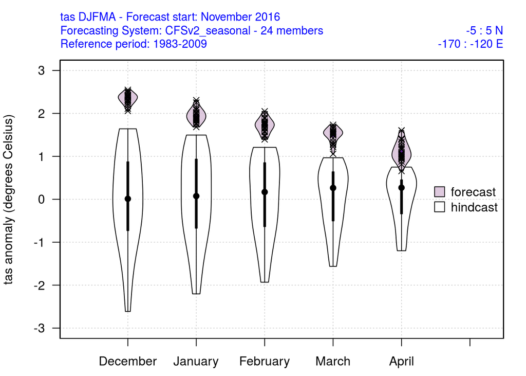

```r
climagram(hindcast = cfs.hindcast, forecast = cfs.forecast, add.points = TRUE)
```

### 2.1.4 Using a target year from the hindcast

Note that a separate operational forecast dataset is not always needed. For testing purposes, an arbitrary year prediction can be withdrawn from the hindcast and being used as forecast using the `year.target` argument. For instance:

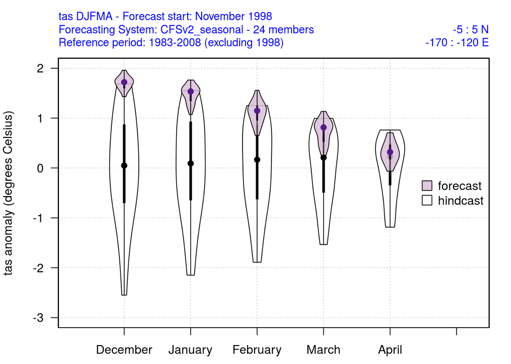

```r
climagram(hindcast = cfs.hindcast, year.target = 1998)
```

Note that in this case, all the statistics computed on the hindcast (and reference observations) are computed excluding the target year.

### 2.1.5 Switching between anomalies and absolute magnitudes

Up to now, anomalies have been displayed. The forecast anomalies are computed considering the hindcast climatology for the reference period. These are computed upon the climatological mean for each month sepparately (although this behaviour could be modified using the `clim.time.frame` argument, internally passed to `time.frame` in `scaleGrid`).

Alternatively, it is also possible to display the original variable magnitude, by setting the argument `use.anomalies` to `FALSE`. The same plot as above, but without anomalies, is thus obtained using:

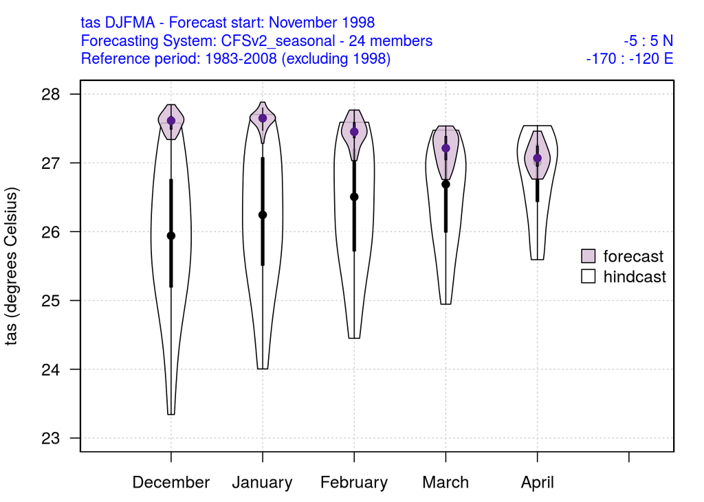

```r
climagram(hindcast = cfs.hindcast, year.target = 1998, use.anomalies = FALSE)
```

### 2.1.6 Detrending

It is also possible to (linearly) detrend the data prior to climagram construction (`detrend = TRUE`), although it has a cost in terms of computing efficiency. To minimize the timing cost, detrending is internally achieved through the `transformeR` function `detrendGrid`, that uses a fast C++ implementation.

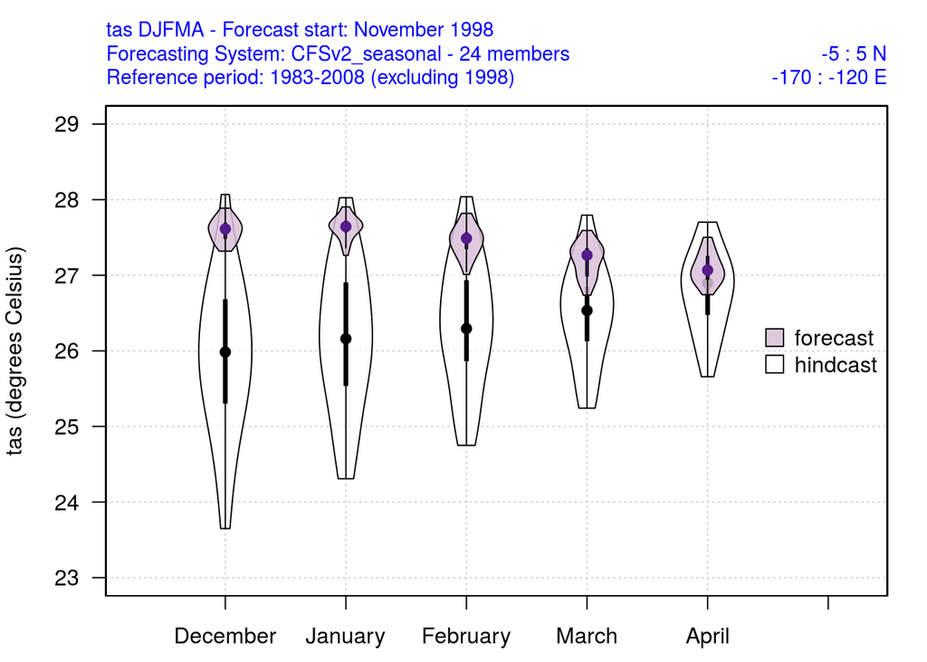

```r
climagram(hindcast = cfs.hindcast, year.target = 1998, use.anomalies = FALSE, detrend = TRUE)
```

Note that if detrending is applied, all the statistics (including EQC information) is computed upon the detrended data.

## 2.2 Including an observed reference

Next, the NCEP reanalysis data used as reference is loaded

```r
obs <- my_load("http://meteo.unican.es/work/visualizeR/data/tas.ncep.enso34.rds")
```

The climatology of the observations is represented by shadowed polygons, differentiating the interquartile range and overall range by gray colors. The median is also depicted by a dashed line.

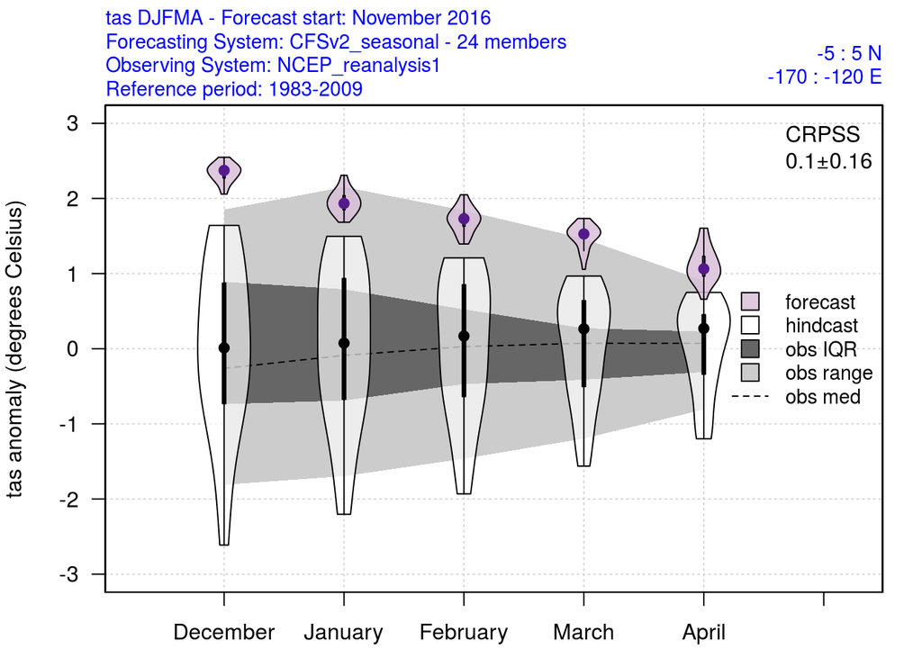

```r
climagram(hindcast = cfs.hindcast, forecast = cfs.forecast, obs = obs)
```

Note that as soon as obs information is included, the EQC info appears on the top right corner. This corresponds to the (fair) CRP Skill Score (an ensemble score), computed with climatology as the reference ($\pm$ s.d.). This choice has been done after internal discussion within the QA4Seas team. To this aim, the `EnsCrps` and `SkillScore` functions from package `SpecsVerification` are used (Siegert 2017). The reference ensemble forecasts based on the available observations, needed to compute the skill score, is generated using the `generateRef` function from package `easyVerification` (MeteoSwiss 2017)

The CRPSS can be omitted if not needed (`add.eqc.info = FALSE`):

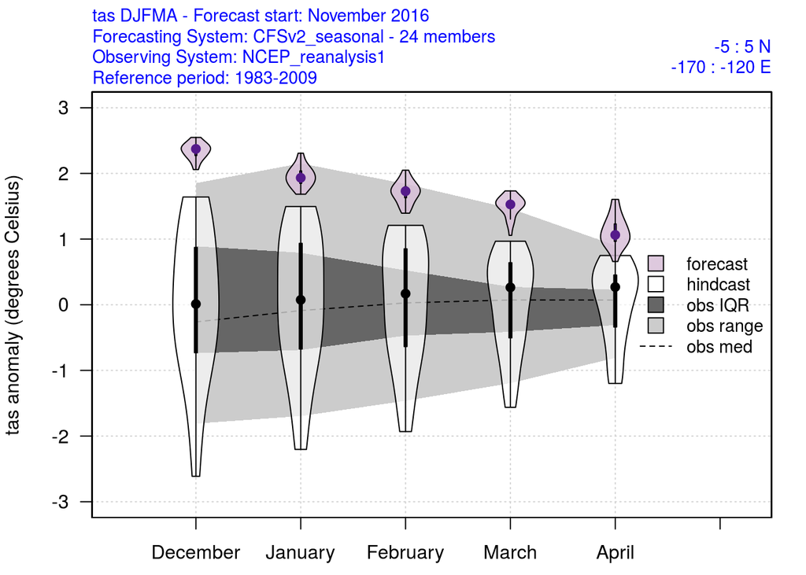

```r
climagram(hindcast = cfs.hindcast, forecast = cfs.forecast, obs = obs, add.eqc.info = FALSE)
```

### 2.2.1 Other customization choices

Inspired by the climagram version produced by MétéoFrance, it is also possible to display the number of forecast members falling within each hindcast tercile. This information is hidden by default, but can be depicted using `tercile.member.counts = TRUE`. Following with the previous example using the target year 1998:

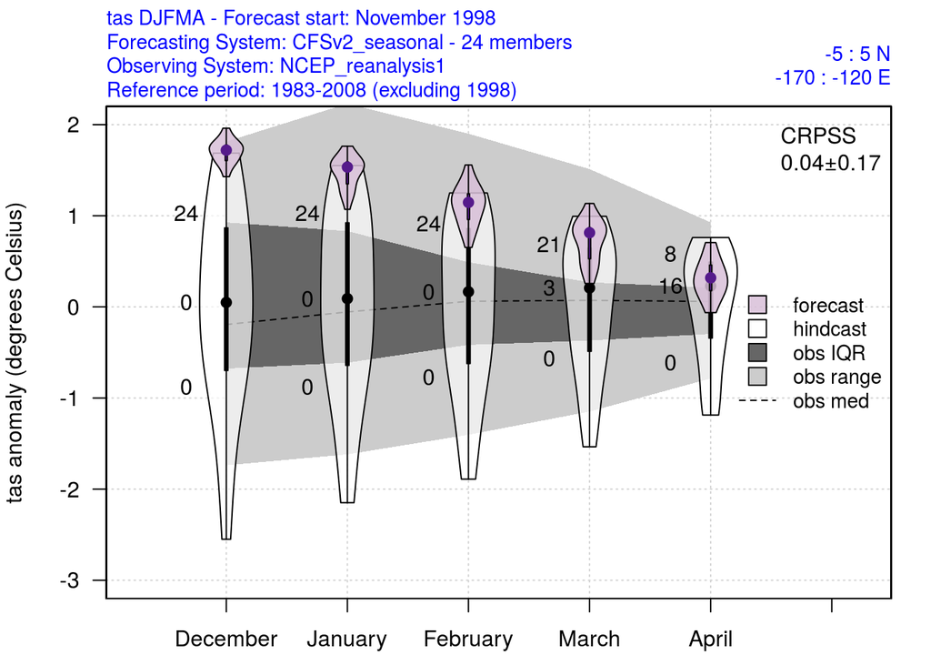

```r
climagram(hindcast = cfs.hindcast, year.target = 1998, obs = obs, tercile.member.counts = TRUE)
```

# 3 Multi-model climagrams

In this section, in addition to CFSv2 hindcast (24 members), we wil use System4 (51 members) and GloSea5 (24 members) to illustrate the application of climagrams to multimodel ensemble predictions.

```r
gs5.hindcast <- my_load("http://meteo.unican.es/work/visualizeR/data/tas.gs5.enso34.rds")
s4.hindcast <- my_load("http://meteo.unican.es/work/visualizeR/data/tas.s4.enso34.rds")
```

Multimodel combination requires a common period. In order to set a common temporal extent for all hindcasts, the function `intersectGrid` is used:

```r
cfs.hindcast <- intersectGrid(cfs.hindcast, gs5.hindcast)
s4.hindcast <- intersectGrid(s4.hindcast, cfs.hindcast)
gs5.hindcast <- intersectGrid(gs5.hindcast, cfs.hindcast)
```

Note that the forecast length of GS5 hindcast is much shorter that the other models (~120 days), and therefore the season length is reduced from DJFMA to just DJF. The period encompassed by the reference reanalysis is also adjusted to match the hindcasts’ common period:

```r
obs <- intersectGrid(obs, cfs.hindcast)
```

## 3.1 Raw multimodel

A raw multimodel is directly constructed by just binding the different hindcasts along their “member” dimension:

```r
mm.hindcast <- bindGrid(cfs.hindcast, s4.hindcast, gs5.hindcast)
```

The new multimodel is formed by a total of 99 members (24+24+51):

```r
getShape(mm.hindcast)
```

```
## member   time    lat    lon
##     99     51     12     54
```

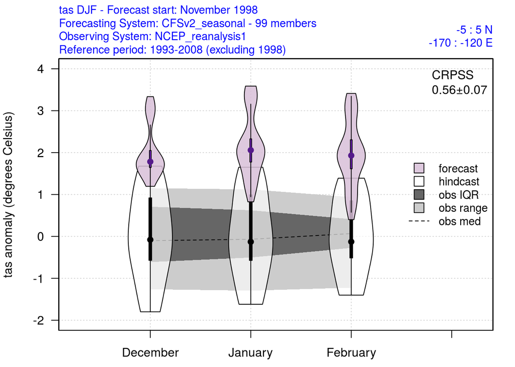

```r
climagram(hindcast = mm.hindcast, year.target = 1998, obs = obs)
```

Given the different systematic model biases, the climagram exhibits a large spread of the hindcast climatology. The forecast data presents a bimodality, due to the larger bias of some model(s). However, the CRPSS is significantly improved as compared to the single-model forecast. The outlying ensemble members (very likely belonging to the same model) are highlighted by ordinary boxplots:

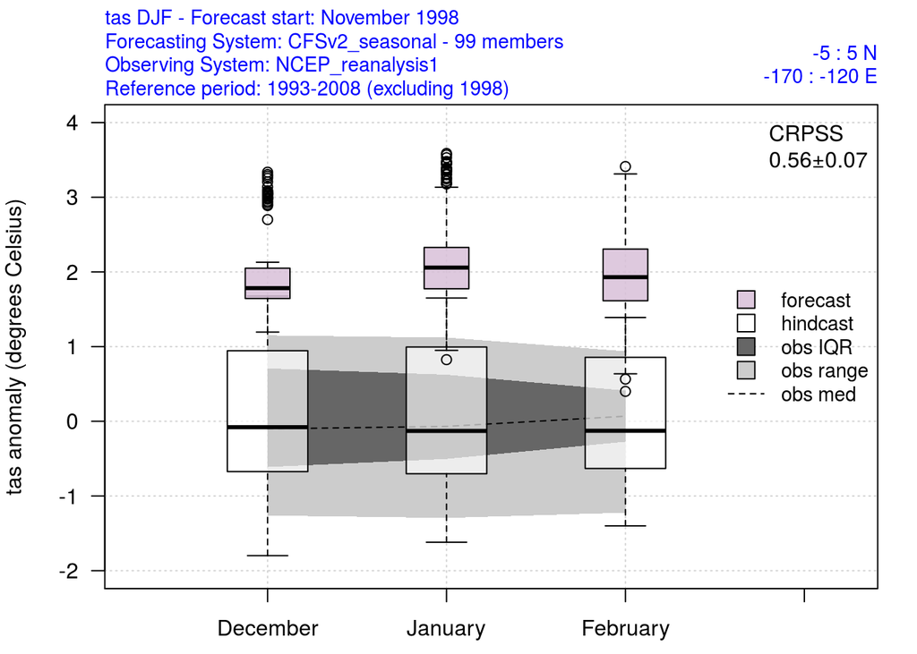

```r
climagram(hindcast = mm.hindcast, year.target = 1998, obs = obs, violin = FALSE)
```

The results can be also analysed in terms of absolute magnitudes instead of anomalies:

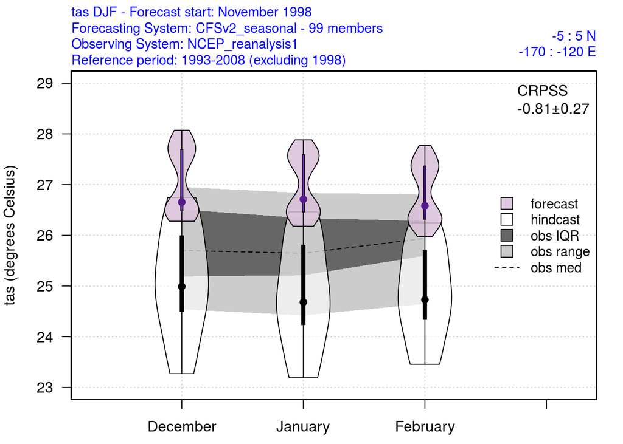

```r
climagram(hindcast = mm.hindcast, year.target = 1998, obs = obs, use.anomalies = FALSE)
```

Thusº, climagrams are not suitable to represent the result of raw ensemble forecasts, and some form of calibration is needed.

## 3.2 Calibrated multimodel

A comprehensive analysis of the benefits of different recalibration and bias adjustmet techniques has been done in QA4Seas Deliverable 31, further developed and presented in Manzanas *et al.* (submitted). More sophisticated methods may improve the multi-model distribution in occasions, although in the overall, simple debiasing (MVA method, mean-variance adjustment) seems to be a good benchmark for model postprocessing as it provides a trade-off between simplicity and performance. In addition to MVA, we test the Climate Conserving Recalibration (CCR; Weigel *et al.* 2009, introduced by Doblas-Reyes *et al.* 2005 as “variance inflation”), to illustrate the use of alternative adjustment techniques beyond simple debiasing.

### 3.2.1 Mean-variance adjustment

```r
fun = list(FUN = "mean")
x <- aggregateGrid(cfs.hindcast, aggr.mem = fun, aggr.lat = fun, aggr.lon = fun)[["Data"]]
ks.test(x, y = "pnorm")
```

```
##
##  One-sample Kolmogorov-Smirnov test
##
## data:  x
## D = 1, p-value = 6.661e-16
## alternative hypothesis: two-sided
```

```r
xobs <- aggregateGrid(obs, aggr.lat = fun, aggr.lon = fun)[["Data"]]
ks.test(xobs, y = "pnorm")
```

```
##
##  One-sample Kolmogorov-Smirnov test
##
## data:  xobs
## D = 1, p-value = 6.661e-16
## alternative hypothesis: two-sided
```

Here, we apply the MVA implementation in the function `calMVA` from package `calibratoR`:

```r
library(calibratoR)
cfs.deb <- calMVA(cfs.hindcast, obs)
s4.deb <- calMVA(s4.hindcast, obs)
gs5.deb <- calMVA(gs5.hindcast, obs)
```

The multimodel is constructed upon the debiased hindcasts:

```r
mm.hindcast.deb <- bindGrid(cfs.deb, s4.deb, gs5.deb, dimension = "member")
```

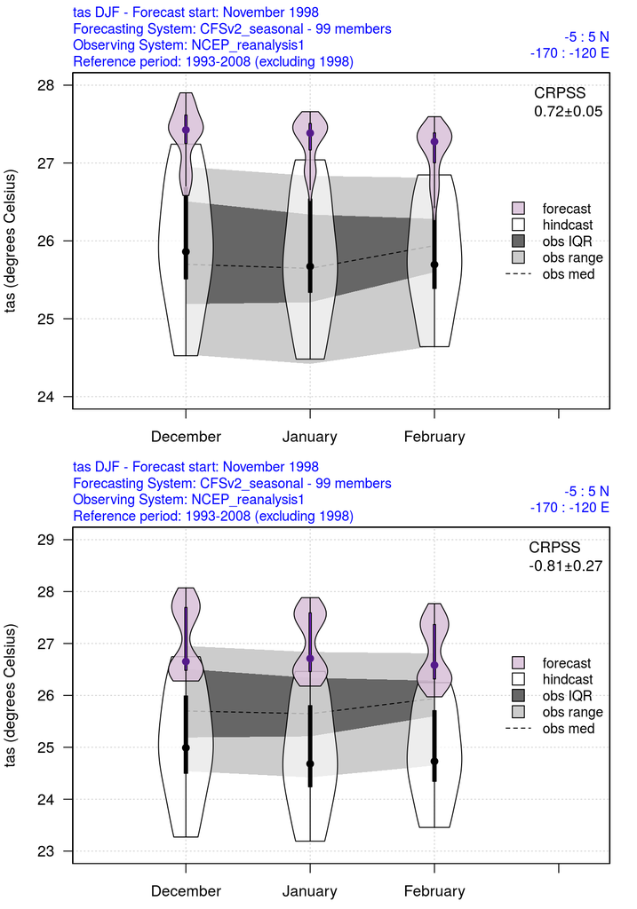

*Multi-model ensemble climagrams using absolute forecast variable (2-m air temperature) magnitudes. The multimodel ensemble is composed by NCEP-CFSv2 (24 members), ECMWF-System4 (51 members) and UKMO-GloSea5 (24 members). Ensemble Top: Debiased multimodel forecast. Bottom: Raw multimodel forecast*

```r
par(mfrow = c(2,1))
climagram(hindcast = mm.hindcast.deb, year.target = 1998, obs = obs, use.anomalies = FALSE)
climagram(hindcast = mm.hindcast, year.target = 1998, obs = obs, use.anomalies = FALSE)
```

As depicted in the figure above, MVA (top) centers the hindcast in alignment with the reference observations. It is also noticeable an improvement of the CRPSS w.r.t. its raw counterpart (bottom).

### 3.2.2 Climate Conserving Recalibration

The CCR approach has been recently applied in seasonal forecasting (e.g. Torralba *et al.* (2017) to produce reliable operational seasonal forecasts of wind speed. It is implemented in `calibratoR` through the function `calCCR`:

```r
cfs.ccr <- calCCR(cfs.hindcast, obs)
s4.ccr <- calCCR(s4.hindcast, obs)
gs5.ccr <- calCCR(gs5.hindcast, obs)
```

A new multimodel is constructed using the CCR-adjusted hindcasts:

```r
mm.hindcast.ccr <- bindGrid(cfs.ccr, s4.ccr, gs5.ccr, dimension = "member")
```

Next, we represent the three combination approaches tested (raw, MVA and CCR-adjusted forecasts) together in the same plot, for a better visual comparison. As it can be seen, the CCR approach provides no clear improvement w.r.t the much simpler (and faster) MVA:

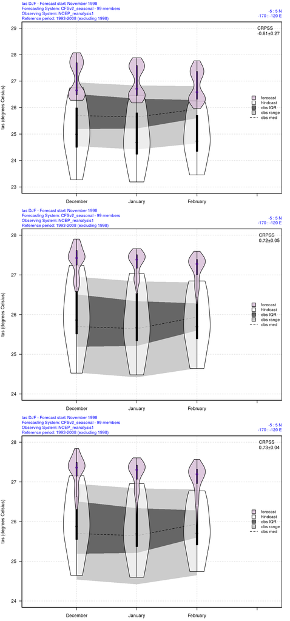

*Multi-model ensemble climagrams using absolute forecast variable (2-m air temperature) magnitudes. The multimodel ensemble is composed by NCEP-CFSv2 (24 members), ECMWF-System4 (51 members) and UKMO-GloSea5 (24 members). Top: Raw multimodel forecast. Center: Debiased forecast (MVA-method). Bottom: Calibrated forecast (CCR method)*

```r
par(mfrow = c(3,1))
climagram(hindcast = mm.hindcast, year.target = 1998, obs = obs, use.anomalies = FALSE)
climagram(hindcast = mm.hindcast.deb, year.target = 1998, obs = obs, use.anomalies = FALSE)
climagram(hindcast = mm.hindcast.ccr, year.target = 1998, obs = obs, use.anomalies = FALSE)
```

As noted by Manzanas *et al.* (submitted), there is no clear added value of CCR w.r.t. the simpler MVA debiasing.

# 4 References

- Cofiño, A.S., *et al.*, 2018. The ECOMS User Data Gateway: Towards seasonal forecast data provision and research reproducibility in the era of Climate Services. Climate Services 9, 33–43. https://doi.org/10.1016/j.cliser.2017.07.001
- Doblas-Reyes, F.J., Hagedorn, R., Palmer, T.N., 2005. The rationale behind the success of multi-model ensembles in seasonal forecasting–II. Calibration and combination. Tellus A 57, 234–252.
- Frías, M.D. *et al.*, 2018. An R package to visualize and communicate uncertainty in seasonal climate prediction. Environmental Modelling & Software 99, 101-110. https://doi.org/10.1016/j.envsoft.2017.09.008
- Leung, L. R., A. F. Hamlet, D. P. Lettenmaier, and A. Kumar, 1999: Simulations of the ENSO hydroclimate signals in the Pacific Northwest Columbia River basin. Bull. Amer. Meteor. Soc., 80, 2313–2329, doi:10.1175/1520-0477(1999)080<2313:SOTEHS>2.0.CO;2.
- Manzanas, R., Bhend, J. and Torralba, V., 2018. calibratoR: An R package for statistical calibration of seasonal climate forecasts. R package version 0.1.1. https://github.com/SantanderMetGroup/calibratoR
- Manzanas, R., Gutiérrez, J.M., Bhend, J. , Hemri, S., Doblas-Reyes, F.J., Torralba, V, Penabad, E. and Brookshaw, A., 2018: “Bias adjustment and ensemble recalibration methods for seasonal forecasting: A comprehensive intercomparison using the C3S dataset”, submitted to Climate Dynamics.
- MeteoSwiss, 2017. easyVerification: Ensemble Forecast Verification for Large Data Sets. R package version 0.4.4. https://CRAN.R-project.org/package=easyVerification
- Siegert, S., 2017. SpecsVerification: Forecast Verification Routines for Ensemble Forecasts of Weather and Climate. R package version 0.5-2. https://CRAN.R-project.org/package=SpecsVerification
- Torralba, V., F.J. Doblas-Reyes, D. MacLeod, I. Christel, and M. Davis, 2017: Seasonal Climate Prediction: A New Source of Information for the Management of Wind Energy Resources. J. Appl. Meteor. Climatol., 56, 1231–1247, https://doi.org/10.1175/JAMC-D-16-0204.1
- Weigel, A.P., M.A. Liniger, and C. Appenzeller, 2009: Seasonal ensemble forecasts: Are recalibrated single models better than multimodels? Mon. Wea. Rev., 137, 1460-1479, https://doi.org/10.1175/2008MWR2773.1